# Split-Plot Designs

Part 1: Concepts, Randomization & Error Structure | Week 8 — AGST 50104

Dr. Samuel B Fernandes

2026-01-01

## Learning Objectives

By the end of this lecture, you should be able to:

- Recognize when experimental constraints require split-plot designs and distinguish whole-plot from subplot factors
- Describe the two-stage randomization procedure and implement it in R
- Write the split-plot statistical model as two nested sub-models and identify each error term
- Construct the ANOVA table with correct degrees of freedom and F-test denominators

# Part 1: Why Split-Plot?

## From Factorial to Split-Plot: The Problem

**Ideal Factorial (Fully Independent):**

- Irrigation: 2 levels (Drip, Furrow)
- Nitrogen: 4 levels (0, 50, 100, 150 kg/ha)
- Total combinations: 2 × 4 = 8
- 3 reps × 8 combos = **24 experimental units**

Each of the 24 units gets independently assigned one combination of irrigation AND nitrogen.

## From Factorial to Split-Plot: The Reality

**What the statistician wants:**

- 24 independently randomized plots
- Each plot gets a unique irrigation + nitrogen combo
- Complete randomization of all 8 treatments

**Cost:** 24 separate irrigation installations at ~$5,000 each = **$120,000**

**What the field researcher can afford:**

- Installing/changing irrigation is **hard & expensive**
- Setting nitrogen fertilizer is **easy & cheap**
- Only budget for 6 irrigation setups (3 reps × 2 levels)
- Within each irrigated area, subdivide for nitrogen

**Cost:** 6 irrigation setups + 24 fertilizer applications = **$31,000**

**Split-plot design** accommodates this practical reality without sacrificing the ability to estimate all main effects and interactions.

## Cookie Example: Factorial vs Split-Plot

**Response:** Consistency of chocolate chip cookies

**Factors:** Temperature (3 levels) and amount of baking soda (4 levels)

**Design 1 — Full Factorial:**

12 combinations of temperature and baking soda are replicated three times. You mix up cookie dough and then cook it **36 times** — one batch at a time.

- 36 separate oven runs
- Change temperature between every run
- Each run uses one dough formulation

**Design 2 — Split-Plot:**

Four batches of dough are created, each with a different amount of baking soda. Oven is heated to a specific temperature and the four doughs are put in the oven **at the same time**. Repeat for the other temperatures.

- 36 batches of dough, but only **9 cooking trials**
- **WPF:** Temperature (hard to change — oven takes time to heat/cool)
- **SPF:** Baking soda (easy to change — just mix differently)

## What Makes a Factor “Hard to Change”?

Not all experimental factors are equal. Some require:

- **Large equipment** — tillage implements cover entire field sections
- **Expensive infrastructure** — irrigation system installation ($5K–$10K per plot)
- **Time commitment** — planting date or cover crop (planted months earlier)
- **Physical constraints** — soil amendments that can’t be confined to small areas
- **Safety/regulatory** — fumigation zones requiring buffer distances
- **Thermal inertia** — oven temperature takes time to stabilize (cookie example!)

These factors **cannot** be randomly assigned to small individual plots (or batches).

## Whole-Plot Factors: Definition

**Whole-Plot Factor (WPF):**

- Applied to **large areas** of experimental material
- Difficult or expensive to change during the experiment
- Usually has **fewer levels** to avoid excessive cost

**Agricultural WPF examples:**

| Factor | Why it’s whole-plot |
| --- | --- |
| Tillage method | Large equipment, full-field passes |
| Irrigation system | Infrastructure installation |
| Planting date | Entire field planted at once |
| Seeding rate | Grain drill calibration |
| Cover crop species | Seed bed prep months in advance |

## Subplot Factors: Definition

**Subplot Factor (SPF):**

- Applied to **smaller areas** within each whole-plot
- Easy and cheap to change
- Can have **more levels** without excessive cost

**Agricultural SPF examples:**

| Factor | Why it’s subplot |
| --- | --- |
| Herbicide rate | Plot sprayer, quick to change |
| Fertilizer timing | Hand application or small spreader |
| Seed treatment | Applied before planting |
| Fungicide product | Spray different sections easily |
| POST weed control | Backpack sprayer |

## The Key Distinction

The distinction between whole-plot and subplot is **not** about which factor is more important — it’s about **practical randomization constraints**.

**Example 1 — Weed science:**

- Whole-plot: Tillage (expensive equipment, full-field operation)
- Subplot: Herbicide rate (your primary research interest!)

**Example 2 — Horticulture:**

- Whole-plot: Rootstock type (ordered and planted months in advance)
- Subplot: Pruning method (done by hand on individual plants)

**Example 3 — Food science:**

- Whole-plot: Oven temperature (takes time to change and stabilize)
- Subplot: Coating type (applied to individual samples quickly)

## Real Agricultural Example: Irrigated Wheat

**Research Question:** How do irrigation method and nitrogen timing interact to affect wheat yield?

**Why split-plot?**

- Irrigation system installation: $8,000/plot, takes 1 week
- Nitrogen application: $50/plot, takes 30 minutes
- Field has 6 available spaces for independent irrigation setups

**Design:**

- **Whole-plot factor:** Irrigation (Drip vs Furrow)
  - 2 levels, 3 reps = 6 whole-plots
- **Subplot factor:** N-timing (Pre-plant, Boot, Both)
  - 3 levels within each whole-plot
- **Total observations:** 6 × 3 = 18

## Real Example: Weed Science Palmer Amaranth Study

**Research Question:** Does tillage system interact with POST herbicide rate to suppress Palmer amaranth density?

**Why whole-plot for tillage?**

A single tillage pass covers an entire block section (~3 acres). You can’t till just one 3m × 6m plot.

**Total plots:** 4 × 2 × 3 = **24**

| Factor | Type | Levels |
| --- | --- | --- |
| Tillage | Whole-plot | No-till, Conventional |
| Herbicide rate | Subplot | 0, 280, 560 g ai/ha |
| Blocks (reps) | — | 4 |

## Field Layout: Palmer Amaranth Study

**One block of the split-plot design:**

```
Block 1
┌───────────────────────────────────────┐
│  No-till  (whole-plot 1)              │
│  ┌──────────┬──────────┬──────────┐   │
│  │  0 g/ha  │ 280 g/ha │ 560 g/ha │   │
│  │ subplot 1│ subplot 2│ subplot 3│   │
│  └──────────┴──────────┴──────────┘   │
├───────────────────────────────────────┤
│  Conventional  (whole-plot 2)         │
│  ┌──────────┬──────────┬──────────┐   │
│  │ 280 g/ha │  0 g/ha  │ 560 g/ha │   │
│  │ subplot 1│ subplot 2│ subplot 3│   │
│  └──────────┴──────────┴──────────┘   │
└───────────────────────────────────────┘
```

Notice: herbicide order **differs** between whole-plots — each is randomized independently.

## Four Blocks: Complete Layout

```
Block 1                          Block 2
┌─────────────────────┐          ┌─────────────────────┐
│ No-till              │          │ Conv                 │
│ [0] [280] [560]      │          │ [560] [0] [280]      │
├─────────────────────┤          ├─────────────────────┤
│ Conv                 │          │ No-till              │
│ [280] [0] [560]      │          │ [0] [560] [280]      │
└─────────────────────┘          └─────────────────────┘

Block 3                          Block 4
┌─────────────────────┐          ┌─────────────────────┐
│ No-till              │          │ Conv                 │
│ [560] [280] [0]      │          │ [280] [560] [0]      │
├─────────────────────┤          ├─────────────────────┤
│ Conv                 │          │ No-till              │
│ [0] [560] [280]      │          │ [560] [0] [280]      │
└─────────────────────┘          └─────────────────────┘
```

- 4 blocks × 2 whole-plots × 3 subplots = **24 total observations**
- Tillage assignment to top/bottom varies randomly per block
- Herbicide order varies randomly within each whole-plot

## Yates Oats: A Classic Split-Plot Dataset

**The yield of oats from a split-plot field trial conducted at Rothamsted in 1931.**

- **Varieties** were applied to the main plots (whole-plot factor)
- **Manurial (nitrogen) treatments** were applied to the sub-plots (subplot factor)
- 6 complete blocks

```r
data(yates.oats, package = "agridat")
head(yates.oats)
```

```
#>   row col yield nitro        gen block grain straw
#> 1  16   3    80     0 GoldenRain    B1 20.00 28.00
#> 2  12   4    60     0 GoldenRain    B2 15.00 25.00
#> 3   3   3    89     0 GoldenRain    B3 22.25 40.50
#> 4  14   1   117     0 GoldenRain    B4 29.25 28.75
#> 5   8   2    64     0 GoldenRain    B5 16.00 32.00
#> 6   5   2    70     0 GoldenRain    B6 17.50 27.25
```

## Visualizing the Oats Design with `desplot`

```r
library(desplot)

desplot(yates.oats, block ~ col + row,
        col = nitro, text = gen, cex = 1, aspect = 511/176,
        out1 = block, out2 = gen,
        out2.gpar = list(col = "gray50", lwd = 1, lty = 1),
        main = "Yates Oats Split-Plot Design")
```

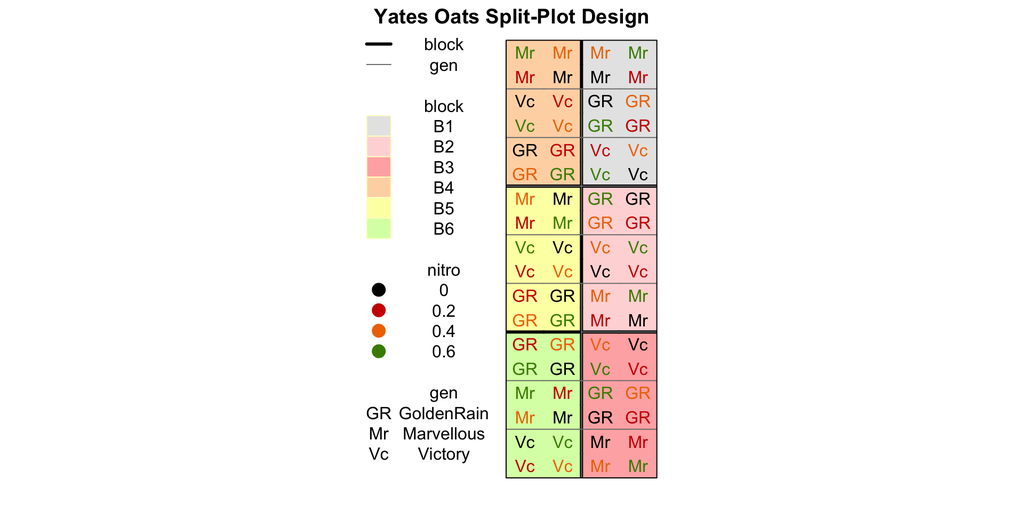

Figure 1: Split-plot layout of the Yates oats trial at Rothamsted (1931)

- **Colored regions + thick outlines** = blocks (replicates)
- **Text codes + thin lines** = whole-plots (variety)
- **Text colors** = nitrogen sub-plot treatments

## Visualizing the Oats Yield Response

```r
desplot(yates.oats, yield ~ col * row,
        col = gen, num = nitro, cex = 1,
        out1 = block, aspect = 511/176,
        main = "Yates Oats: Yield by Field Position")
```

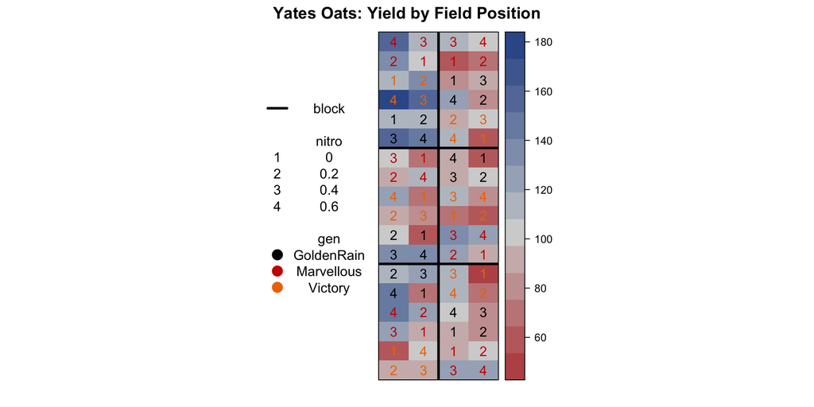

Figure 2: Spatial distribution of oat yield across the field trial

Coloring by a **continuous response** variable (yield) reveals spatial patterns in the field — exactly the kind of variation that blocking accounts for.

# Part 2: Randomization

## Two-Stage Randomization Process

**Stage 1: Assign whole-plot factor to large areas**

- Within each block, randomly assign tillage levels to whole-plot positions
- This is like a simple RCBD for the whole-plot factor

**Stage 2: Within each whole-plot, assign subplot factor**

- Subdivide each whole-plot into smaller subplots
- Randomly assign herbicide rates to subplots
- **Independently** for each whole-plot

**Two-stage means two independent randomizations** — one at the whole-plot level, one at the subplot level. This hierarchy is what defines the split-plot design.

## Using FielDHub for Production Designs

```r
library(FielDHub)

# Generate split-plot design with field layout
sp_design <- FielDHub::split_plot(
  wp = c("No-till", "Conv"),     # Whole-plot levels
  sp = c("0", "280", "560"),     # Subplot levels
  reps = 4,                       # Number of blocks
  seed = 2026
)

# Print the field book
sp_design$fieldBook

# Plot the field layout
plot(sp_design)
```

**FielDHub advantages over manual randomization:**

- Generates physical plot numbers for field maps
- Creates randomization plan documents
- Produces visual field layouts for field crews
- Handles more complex designs (split-split-plot, strip-plot)

# Part 3: Statistical Model

## Building the Model: Step 1 — The Whole-Plot Level

Think of the split-plot as **two experiments nested inside each other**.

**At the whole-plot level**, ignore subplots entirely. You have an RCBD of the WPF across blocks:

$$y_{ik\cdot} = \mu + \underbrace{\alpha_i}_{\text{WPF (tillage)}} + \underbrace{\rho_k}_{\text{block}} + \underbrace{\gamma_{ik}}_{\text{WP error}}$$

| Symbol | Meaning |
| --- | --- |
| $y_{ik\cdot}$ | Mean response of whole-plot $ik$ (averaged across subplots) |
| $\alpha_i$ | Fixed effect of whole-plot factor level $i$ |
| $\rho_k$ | Fixed block effect |
| $\gamma_{ik}$ | Random whole-plot error, $\gamma_{ik} \sim N(0, \sigma^2_{WP})$ |

This is just a standard RCBD — nothing new here.

## Building the Model: Step 2 — The Subplot Level

**Within each whole-plot**, you run a second experiment on the subplot factor:

$$y_{ijk} = y_{ik\cdot} + \underbrace{\beta_j}_{\text{SPF (herbicide)}} + \underbrace{(\alpha\beta)_{ij}}_{\text{interaction}} + \underbrace{\epsilon_{ijk}}_{\text{SP error}}$$

| Symbol | Meaning |
| --- | --- |
| $y_{ijk}$ | Individual subplot observation |
| $\beta_j$ | Fixed effect of subplot factor level $j$ |
| $(\alpha\beta)_{ij}$ | Interaction between WPF and SPF |
| $\epsilon_{ijk}$ | Random subplot error, $\epsilon_{ijk} \sim N(0, \sigma^2_{SP})$ |

Each whole-plot is subdivided — so this second experiment is **nested within** the first.

## The Complete Split-Plot Model

Substituting Step 1 into Step 2 gives the **full model**:

$$\boxed{y_{ijk} = \mu + \rho_k + \alpha_i + \gamma_{ik} + \beta_j + (\alpha\beta)_{ij} + \epsilon_{ijk}}$$

**Whole-plot level terms:**

- $\mu$ — overall mean
- $\rho_k$ — block effect
- $\alpha_i$ — WPF effect (tillage)
- $\gamma_{ik} \sim N(0, \sigma^2_{WP})$ — **WP error**

**Subplot level terms:**

- $\beta_j$ — SPF effect (herbicide)
- $(\alpha\beta)_{ij}$ — interaction
- $\epsilon_{ijk} \sim N(0, \sigma^2_{SP})$ — **SP error**

Two random components → two error terms → two separate F-tests.

## Two Random Components

The model has **two** independent random terms:

$$\gamma_{ik} \sim N(0,\; \sigma^2_{WP}) \qquad \text{(whole-plot error)}$$

$$\epsilon_{ijk} \sim N(0,\; \sigma^2_{SP}) \qquad \text{(subplot error)}$$

**Why two?** Because the experiment has two levels of randomization:

- Between whole-plots → captured by $\gamma_{ik}$
- Within whole-plots → captured by $\epsilon_{ijk}$

All subplots **within the same whole-plot** share the same $\gamma_{ik}$ value. This makes them **correlated** — not independent.

## Whole-Plot Error ($\sigma^2_{WP}$): In Detail

**What it captures:**

- Variation **between** whole-plots that received the **same** treatment
- Example: Drip plot 1 vs Drip plot 2 vs Drip plot 3

**Sources of whole-plot error:**

- Soil heterogeneity across large field areas
- Field position effects (slope, drainage)
- Equipment calibration differences between passes

**Consequence:** This error is typically **large** because whole-plots are big and variable.

→ Fewer effective replicates for the WP factor  
→ **Lower power** for testing whole-plot effects

## Subplot Error ($\sigma^2_{SP}$): In Detail

**What it captures:**

- Variation **within** a whole-plot, after accounting for subplot treatment effects
- Example: Differences among the 3 herbicide subplots within Drip plot 1

**Sources of subplot error:**

- Local micro-environment variation within a whole-plot
- Measurement and sampling error
- Plant-to-plant variability
- Residual unexplained differences

**Consequence:** This error is typically **small** because subplots are close together and share a common environment.

→ More effective replicates for the SPF  
→ **Higher power** for testing subplot effects

## Precision Asymmetry: A Feature, Not a Bug

**Whole-Plot Factor (Tillage):**

- Only 4 data points per level (one per block)
- Tested against larger error ($\sigma^2_{WP}$)
- **Less precision**
- Harder to declare significant

**Subplot Factor (Herbicide):**

- 8 data points per level (4 blocks × 2 tillage levels)
- Tested against smaller error ($\sigma^2_{SP}$)
- **More precision**
- Easier to declare significant

This is **by design**. The split-plot intentionally trades precision on the expensive factor (WPF) for high precision on the cheap factor (SPF). This is an efficient use of limited research budgets.

# Part 4: ANOVA Structure

## ANOVA Table: General Structure

For a split-plot with $a$ WPF levels, $b$ SPF levels, and $r$ blocks:

| Source | df | MS | F denominator |
| --- | --- | --- | --- |
| Blocks | $r - 1$ | $MS_{blk}$ | — |
| **WPF** | $a - 1$ | $MS_W$ | **WP Error** |
| **WP Error** | $(r-1)(a-1)$ | $MS_{WP\,err}$ | — |
| **SPF** | $b - 1$ | $MS_S$ | **SP Error** |
| **WPF × SPF** | $(a-1)(b-1)$ | $MS_{WS}$ | **SP Error** |
| **SP Error** | $a(r-1)(b-1)$ | $MS_{SP\,err}$ | — |
| **Total** | $abr - 1$ | — | — |

**The F-ratios:**

$$F_{WPF} = \frac{MS_W}{MS_{WP\,err}} \qquad F_{SPF} = \frac{MS_S}{MS_{SP\,err}} \qquad F_{int} = \frac{MS_{WS}}{MS_{SP\,err}}$$

## ANOVA: Palmer Amaranth Worked Example

**Design:** $a = 2$ (tillage), $b = 3$ (herbicide), $r = 4$ (blocks)

| Source | df formula | df value |
| --- | --- | --- |
| Blocks | $r - 1$ | $4 - 1 = 3$ |
| Tillage (WPF) | $a - 1$ | $2 - 1 = 1$ |
| WP Error | $(r-1)(a-1)$ | $3 \times 1 = 3$ |
| Herbicide (SPF) | $b - 1$ | $3 - 1 = 2$ |
| Till × Herb | $(a-1)(b-1)$ | $1 \times 2 = 2$ |
| SP Error | $a(r-1)(b-1)$ | $2 \times 3 \times 2 = 12$ |
| **Total** | $abr - 1$ | $24 - 1 = 23$ |

**Verification:** $3 + 1 + 3 + 2 + 2 + 12 = 23$ ✓

## Power Consequences of df

From the Palmer amaranth example:

**Tillage test:**

- Numerator df: 1
- Denominator df: **3** (WP Error)
- Critical F at α = 0.05: **10.13**
- Requires a LARGE effect to be significant

**Herbicide test:**

- Numerator df: 2
- Denominator df: **12** (SP Error)
- Critical F at α = 0.05: **3.89**
- Moderate effects will be detectable

**Translation:** Tillage needs ~2.5× stronger signal than herbicide to reach significance. This is the built-in trade-off of the split-plot design.

## References

- **Oehlert, G. W.** (2010). *A First Course in Design and Analysis of Experiments.* Chapter 7: Split-Plot, Strip-Plot, and Related Designs. Available: http://users.stat.umn.edu/~gary/book.html
- **Dean, A. M., Voss, D., & Draguljić, D.** (2017). *Design and Analysis of Experiments* (2nd ed.). Chapter 9.
- **Montgomery, D. C.** (2019). *Design and Analysis of Experiments* (9th ed.). Chapter 14.
- **R packages:** `dplyr`, `tidyr`, `FielDHub` (design generation), `desplot` (field layout visualization), `agridat` (agricultural datasets)